# SimCRC Chile and USA calibration update

Updated USA calibration: 26 October 2026

SimCRC team

2026-11-05

## USA R versus C++ natural history

## Calibration inputs and scope

| Parameter source | Previous comparison | Updated comparison |
| --- | --- | --- |
| USA | Published set v0.13.0.1 | 26 October 2026, v0.15.0 |
| Chile | 21 September 2026, v0.15.0 | Same Chile set |

The cheat sheet compares the updated USA set with the September Chile set.

**Natural history:** one million simulated women per country, without screening.

**Life tables:** Chile 2017 and USA 1977, preserving the original cheat-sheet assumptions.

Both countries use the female adenoma model. Adenomas are precancerous polyps. The cheat sheet uses the parameter sets selected for the smallest absolute calibration error.

## Chile internal validation: numerical targets

**Chile calibration**

21 September 2026 v0.15.0

**Numerical targets**

Incidence per 100,000.

Prevalence as proportions.

## Chile internal validation: categorical targets

**Chile calibration**

21 September 2026 v0.15.0

**Categorical targets**

Polyp size and cancer-stage proportions.

## Natural-history cheat sheet

## Dwell time and sojourn time

**Total dwell:** polyp formation to symptomatic diagnosis. **Sojourn:** cancer onset to symptomatic diagnosis.

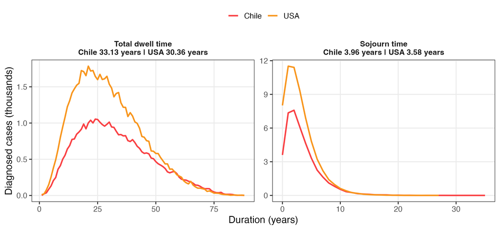

Means describe the polyp that triggered diagnosis: 40,159 Chile cases and 61,601 USA cases.

## Phases of dwell time

Each interval is calculated within the same diagnosing polyp before averaging across cases.

| Phase | Interval | Chile, years | USA, years |
| --- | --- | --- | --- |
| Small adenoma | Polyp onset to 6 mm | 5.03 | 9.36 |
| Medium adenoma | 6 mm to 10 mm | 7.82 | 8.26 |
| Large adenoma | 10 mm to cancer onset | 16.32 | 9.16 |
| Sojourn | Cancer onset to diagnosis | 3.96 | 3.58 |
| Total dwell | Polyp onset to diagnosis | 33.13 | 30.36 |

Chile’s longer total interval mainly comes from the **large-adenoma phase**, partly offset by its shorter early growth phases.